# Interim Review

Scholarly work

Aaron Conway

June 2021

# Overview

My research aims to improve outcomes for patients undergoing procedures with sedation. This program of research was heavily influenced by my clinical experience working as a nurse in the cardiac catheterization laboratory. Prior to joining Bloomberg Nursing and the Peter Munk Cardiac Centre in my role as RBC Chair in Cardiovascular Nursing Research in September 2018, I practiced as a Registered Nurse in the cardiac catheterization laboratory (CCL) setting in Australia for more than 10 years. I was actively involved in clinical research throughout this time. Through my clinical and research experience, I have developed an in-depth understanding of challenges associated with operational issues as well as practical insights into feasible and effective approaches to the conduct of nursing research within this setting. This first-hand practical knowledge and experience ensures the research I undertake is pragmatically designed to optimize participant recruitment, data collection and outcome measurement procedures.

Since my arrival in Canada, I have established new collaborations with researchers and clinicians who posses the complementary expertise required to make significant contributions to the evidence base underlying procedural sedation and analgesia. These include clinical collaborators within the discipline of nursing, as well as in the field of radiology and anesthesiology, but also academic collaborators from computer science and engineering departments at the University of Toronto. Notably, collaborating with these researchers from diverse fields has enabled me to pursue several new projects that leverage machine learning to create innovative solutions for the common problems encountered in procedural sedation.

In my research career to date, I have published 52 peer-reviewed, full-length journal articles, two editorials and a book chapter. I am the principal author for a large majority of these research outputs. As of June 8, 2021, I have 533 citations of my work listed in the Scopus database with a *h*-index of 12. Google scholar metrics include 1016 citations to my work with a *h*-index of 16. My research has produced high quality evidence to support clinician’s decision-making regarding approaches for procedural sedation. This includes two randomized controlled trials, as well as multiple systematic reviews with meta-analyses, including a Cochrane review.

**Scholarly work undertaken at the University of Toronto**

Since I joined the University of Toronto in September 2018, I have published 18 journal articles, one editorial and one book chapter. Notable publications in highly-ranked journals include a randomized controlled trial in the *European Journal of Anaesthesiology* and a meta-analysis in *Thorax*. The scholarly work I have undertaken, which is directed at improving outcomes for patients receiving procedural sedation and analgesia, is primarily organized into the categories of respiratory monitoring and management, sedation monitoring and pre-procedure fasting. Following is a summary of my research in these areas, including publications to date, as well as directions for future research.

# Monitoring for respiratory depression

**Overview**

I am leading a program of research aiming to optimize the use of capnography for monitoring respiratory depression. The program is quite mature. Initial work involved a meta-analysis published in a highly-ranked journal in the field of Anesthesiology, followed by an observational study funded by my NHMRC Early Career Fellowship, which resulted in two publications (during my term at UofT), with a further paper under review. This strong foundation was successfully leveraged to attract funding from Medtronic for a randomized controlled trial. The trial is on track to start in the Fall.

Another aspect of this program of research involves investigating the potential for using machine learning to predict the duration of apneic events as a way to improve capnography alarm performance characteristics, decrease alarm fatigue and improve patient safety. It is planned to build this line of research on integrating predictions from machine learning models into capnography alarm management towards a point where it is possible to evaluate the efficacy of this approach in a randomized controlled trial. Randomized controlled trials testing alarm conditions that have integrated predictions from machine learning models have been conducted previously in similar contexts, such as intra-operative blood pressure management.

Below are summaries of current and completed projects, which I have worked on during my appointment at the University of Toronto.

## A parallel cluster-randomized trial of the Integrated Pulmonary Index for nurse-administered procedural sedation

[figure not shown]

In progress

Role

Principal Investigator

Collaborators

Dr Matteo Parotto  
Consultant Anesthesiologist | Department of Anesthesiology | University of Toronto and Toronto General Hospital  
Dr Sebastian Mafeld  
Interventional Radiologist | Joint Department of Medical Imaging | University of Toronto & Toronto General Hospital

Funding

Funding has been received from the Medtronic External Research Program. A total of $63,500 to support direct research costs and ~$60,000 worth of equipment has been awarded.

**Overview**

Aim: To determine if smart alarm guided treatment of respiratory depression using the Integrated Pulmonary Index is an effective way to implement capnography during nurse-administered sedation.

Design: A parallel cluster randomized trial design will be used. Capnography monitoring will be implemented as standard practice for all patients undergoing procedures with nurse-administered sedation in the four departments participating in the study. Nurses working in the departments will be invited to participate in the randomized controlled trial component of the study. If they choose to participate, they will be randomized to use capnography either with or without the Integrated Pulmonary Index (IPI) enabled.

Setting: Participants will be enrolled from four departments across UHN. The departments include the Cardiac Catheterisation Laboratory and Interventional Radiology departments at the Toronto General Hospital, as well as the Interventional Radiology departments at the Toronto Western Hospital and Mt Sinai Hospital.

Sample size: 400 participants.

Publication plan: It is anticipated that there would be at least two publications in academic journals. One would be focused on the main comparisons in alarm metrics between departments randomized to having IPI enabled or disabled. The other publication would be focused on the insights gained from the intensive facilitated implementation process.

**Current progress**

The ethics application is currently under review. Anticipated start date Fall, 2021.

## Predicting prolonged apnea during nurse-administered procedural sedation

[figure not shown]

Complete

Role

Principal Investigator

Collaborators

Dr Matteo Parotto  
Consultant Anesthesiologist | Department of Anesthesiology | University of Toronto and Toronto General Hospital  
Dr Sebastian Mafeld  
Interventional Radiologist | Joint Department of Medical Imaging | University of Toronto & Toronto General Hospital

Funding

Bertha Rosenstadt Small Research Grant ($5,000)

Data collection was undertaken in Australia, during my term as a Research Fellow at QUT, which was funded by a NHMRC Early Career Fellowship. The analyses and writing components were undertaken at UofT.

**Overview**

Deciphering which capnography waveform abnormalities deserve intervention, and therefore alarms to signal the event to clinicians, from those that do not is an essential step towards successfully implementing this technology into practice. It is possible that capnography alarm management may be improved by using machine learning to create a ‘smart alarm’ that can alert clinicians for apneic events that are predicted to be prolonged. The aim of this study was to determine the accuracy of machine learning models for predicting, at the 15-second time point, if apnea will be prolonged (defined as apnea that persisted for 30 seconds or more). A secondary analysis of an observational study was conducted. Decision curve analysis indicated that using a random forest model would lead to a better outcome (in terms of the balance between false positive and negative predictions) for capnography alarm management compared to an aggressive strategy where alarms are triggered after 15 seconds of apnea. The model would not be superior to the conservative strategy, where alarms are only triggered after 30 seconds.

**Future directions**

Results from these analyses are promising. Longer term plans for this program of research are to undertake a similar analysis using a larger sample in a different population (outlined below) to confirm that predictions of apnea duration are accurate enough to optimize capnography alarm conditions.

Publications

Predicting prolonged apnea during nurse-administered procedural sedation: a machine learning study (Preprint)  
*Under review*  
**Aaron Conway** | Carla Jungquist | Kristina Chang | Navpreet Kamboj | Joanna Sutherland | Sebastian Mafeld | Matteo Parotto

Sequence analysis of capnography waveform abnormalities during nurse-administered procedural sedation and analgesia in the cardiac catheterization laboratory  
*Scientific Reports*  
**Aaron Conway** | Peter Collins | Kristina Chang | Sebastian Mafeld | Joanna Sutherland | James Fingleton

Pre-apneic capnography waveform abnormalities during procedural sedation and analgesia  
*Journal of Clinical Monitoring and Computing*  
**Aaron Conway** | Peter Collins | Kristina Chang | Sebastian Mafeld | Joanna Sutherland | James Fingleton | Matteo Parotto

## Improving capnography alarm management on inpatient wards by predicting the duration of apnea

[figure not shown]

In progress

Role

Principal Investigator

Collaborators

Dr Carla Junquist  
Associate Professor | The University at Buffalo  
Dr Matteo Parotto  
Consultant Anesthesiologist | Department of Anesthesiology | University of Toronto and Toronto General Hospital

**Overview**

Based on results from my prior work outlined above, it seems that using information about the history of previous respiratory states may be a promising solution in regards to predicting durations of apneic periods. I now plan to build on these preliminary findings by building a predictive model from a larger sample of participants.

A secondary analysis of data collected as part of an international prospective observational trial of opioid-induced respiratory depression on inpatient wards (the PRODIGY study) will be conducted. PRODIGY was a prospective trial conducted at 16 clinical sites in the United States, Europe, and Asia. It was performed between April 2017 and May 2018 (ClinicalTrials.gov: NCT02811302) and was funded by Medtronic.

This secondary analysis aims to develop and validate a model for predicting the duration of apnea in patients receiving opioids on inpatient wards. The prediction goal is the duration of apneic events. It is proposed that these predictions could be useful for clinical practice if operationalized as a ‘smart-alarm’ by triggering an alert if an apneic event is predicted to last for more than 20 seconds. The predictions will be compared against a *default* alarm setting for capnography monitors, which triggers an alarm at 30 seconds of apnea. A *correct* prediction for both settings will be when apnea continues for a further 20 seconds or more after the alert is triggered.

**Progress**

Dr Carla Jungquist, who was a PI on the PRODIGY study, has received a contract from Medtronic permitting our use of data from the study for the proposed secondary analysis. It is planned for the analyses to be completed within one year (estimated completion date completion Summer 2022).

# Treating respiratory depression

## High flow nasal oxygen during procedural sedation for cardiac implantable electronic device procedures: A randomised controlled trial.

[figure not shown]

Completed

Role

Principal Investigator

Collaborators

Dr Matteo Parotto  
Consultant Anesthesiologist | Department of Anesthesiology | University of Toronto and Toronto General Hospital

Funding

Connaught New Researcher Award - $19,000

**Overview**

High flow nasal oxygen (HFNO) is increasingly regarded as a promising technology for oxygen delivery in critical care and anesthetic management. The 2018 guidelines from the American Society of Anesthesiology for procedural sedation stated that there is insufficient evidence regarding which methods of supplemental oxygen administration (e.g., nasal cannula, face mask, or specialized devices such as HFNO) are more effective. This trial addressed this limitation in the evidence base specifically in regard to the efficacy of using HFNO during conscious sedation in the cardiac catheterisation laboratory.

Publications

High flow nasal oxygen during procedural sedation for cardiac implantable electronic device procedures  
*European Journal of Anaesthesiology*  
**Aaron Conway** | Peter Collins | Kristina Chang | Navpreet Kamboj | Ana Lopez Filici | Phoebe Lam | Matteo Parotto

## Peripheral electrical stimulation for sedation-induced respiratory depression during procedural sedation and analgesia

[figure not shown]

In progress

Role

Principal Investigator

Collaborators

Dr Matteo Parotto  
Consultant Anesthesiologist | Department of Anesthesiology | University of Toronto and Toronto General Hospital  
Prof J. Stewart Aitchison  
Department of Electrical & Computer Engineering | University of Toronto

**Overview**

Sedation-induced respiratory depression is common during procedures performed with procedural sedation. This project aims to develop a closed-loop system capable of delivering low-level peripheral electrical stimuli (PES) when respiratory depression is detected. A transcutaneous carbon dioxide (TcCO<sub>2</sub>) monitoring system will be used to detect respiratory depression. Specifically, the PES will be triggered when the rise in TcCO<sub>2</sub> over a specified interval has exceeded a set threshold. An analysis of TcCO<sub>2</sub> monitoring data from ~200 patients in our previous studies will be used to guide the identification of an optimal threshold for detection of respiratory depression.

**Progress**

This project builds on a published systematic review (details below), but is still very early in its development phase. In collaboration with Prof Aitchison, we have advertised the project within the Department of Electrical & Computer Engineering to recruit students to work on developing a prototype for the technology. Future plans will be to move towards testing the device clinically before applying for funding to evaluate the efficacy of the device in a randomized controlled trial.

Publications

Accuracy and precision of transcutaneous carbon dioxide monitoring: a systematic review and meta-analysis  
Thorax  
**Aaron Conway** | Elizabeth Tipton | Wei-Hong Liu | Zachary Conway | Kathleen Soalheira | Joanna Sutherland | James Fingleton

# Sedation monitoring

## Automating sedation state assessment

[figure not shown]

In progress

Role

Principal Investigator

Collaborators

Dr Babak Taati  
Scientist | KITE | Toronto Rehabilitation Institute  
Assistant Professor | Department of Computer Science | Institute of Biomedical Engineering (BME) | University of Toronto  
Dr Sebastian Mafeld  
Interventional Radiologist | Joint Department of Medical Imaging | University of Toronto & Toronto General Hospital

Funding

**Overview**

The ideal procedural sedation assessment measures a variety of factors, such as control of movement, stress, and pain, while at the same time allowing for categorization of respiratory depression or other adverse or unintended physiological effects related to the administration of sedative and analgesic medications. With the recent advances in machine learning technology, it may be possible to automate all, or particular aspects, of procedural state assessments in real-time. Such a system would have multiple potential benefits and possibilities for future investigation. If the sedation state assessment technology is sufficiently accurate to implement into clinical practice, with time, enough data may be accrued to build predictive models for the timing of state transitions. Predictions about the probability of an impending state transition could be operationalized into real-time clinical decision-making support systems. Receiving an alert that there is a high probability of an impending state transition would allow clinicians to initiate interventions, such as titration of sedation or analgesia, and potentially prevent the occurrence of a ‘problem’ state, thus increasing the time spent in an ‘ideal’ sedation state.

A pilot study is in progress to investigate the feasibility of developing an automated sedation state assessment system from audiovisual recordings made during procedures performed with sedation in Interventional Radiology. Results will inform the development of technology capable of automating sedation state assessment during procedures.

Aims for the pilot study are to:

**Progress**

This study is currently in progress. We were able to recruit 5 participants (100% recruitment rate) prior to clinical research being shut down at Toronto General Hospital for the third COVID wave. It is anticipated that once clinical research restarts, we would be able to complete data collection within a period of 6 months.

# Automating pre-procedure fasting instructions

**Overview**

Instructions about when to stop eating and drinking before a medical procedure performed with sedation or anaesthesia are not usually updated to account for delays and rescheduling, so most patients go without eating or drinking for much longer than is required. This project focuses on enabling compassionate healthcare using digital technology integrated with AI by setting up a real-time instruction system (Figure 1). It will predict procedure start time and automate the instructions sent to patients about when they should stop eating or drinking before their procedure.

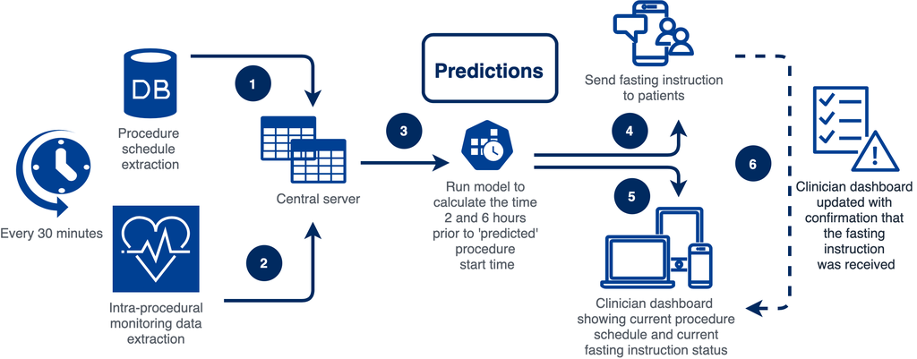

Figure 1: Automated pre-procedure fasting instruction system

Specific objectives for current research activities are to:

- Build a model using state-of-the-art machine learning methods to predict the time 2 and 6 hours before actual procedure start times using predictor variables drawn from the hospital scheduling and intra-procedure monitoring systems.
- Identify design specifications for the user-facing components of an automated fasting instruction system that is optimally suited to patient and clinician requirements.

This approach will ensure the alert system is optimally suited to patient and healthcare team requirements for providing the automated pre-procedural fasting instructions. *Long-term, it is planned to evaluate the effectiveness of this automated system in a randomized controlled trial prior to broader implementation.*

Although funding applications for this project have been unsuccessful to date (details below), I have arranged to move forward using resources provided by my appointment as RBC Chair of Cardiovascular Nursing, and through a collaboration with Prof Chris Beck. Dr. Beck is perfectly situated to collaborate on this research. He is an expert in Artificial Intelligence and Operations Research focused primarily on the algorithms, mathematics, and applications of scheduling and planning. Dr. Beck’s research seeks to combine insights from combinatorial optimization, AI, and operations research to develop theoretical and application-based techniques to improve schedule performance and reduce resource usage across domains including healthcare, energy, cloud systems, transportation, and manufacturing. A student with appropriate expertise has been accepted by Professor Christopher Beck to join his lab, the Toronto Intelligent Decision and Engineering Laboratory, in the fall of 2021 to work on this project.

| Date | Role | Grant scheme | Amount | Status |
| --- | --- | --- | --- | --- |
| Spring 2020 | PI | CIHR Project Grant | $260,000 | Unsuccessful |
| Fall 2020 | PI | NFRF Exploration 2020 | $225,000 | Unsuccessful |
| Spring 2021 | PI | AMS Healthcare Small Grant in Compassion and Artificial Intelligence | $20,000 | Submitted |

Outlined below are completed and current studies related to this broad research aim. After completion of these studies, it is planned to apply for funding to conduct a randomized controlled trial of the automated pre-procedure fasting instruction system.

## Validating the Peri-operative Thirst Discomfort Scale

[figure not shown]

Completed

Role

Principal Investigator

Collaborators

Dr Matteo Parotto  
Consultant Anesthesiologist | Department of Anesthesiology | University of Toronto and Toronto General Hospital  
Dr Sebastian Mafeld  
Interventional Radiologist | Joint Department of Medical Imaging | University of Toronto & Toronto General Hospital

**Overview**

This preliminary project has provided us with a validated instrument to use in our future studies to evaluate the impact of the automated fasting instruction.

Publications

Validating the Peri-operative Thirst Discomfort Scale for Measuring Thirst Discomfort Prior to Procedures  
*Journal of Radiology Nursing*  
**Aaron Conway** | Kristina Chang | Megan Bittner | Dan Phan | Navpreet Kamboj | Matteo Parotto | Amanda Matthews | Sheryl Alexandre | Shahvand Masihi | Sebastian Mafeld

## Co-designing an Automated Pre-Procedure Fasting Instruction System

[figure not shown]

In Progress

Role

Principal Investigator

Collaborators

Julie Vizza  
Patient partner | Patient partner program | University Health Network

**Overview**

The objective of this study will be to examine patient, informal patient caregiver, and staff clinician preferences on the delivery of notifications for an automated pre-procedure fasting instruction system. These design specifications will be informed by the scenarios created by patient and caregiver participants, and the interview responses of clinician participants. The results of this study (e.g., the design specifications) will provide specific, actionable ways for the research team to operationalize patient, caregiver and clinician-centred and prioritized ideas in the design of an automated pre-procedure fasting instructions system.

**Progress**

Data collection has commenced, with 4 patient participants recruited to date. Unfortunately, progress was considerably impacted due to clinical disruption at Toronto General Hospital for COVID-19.

## Predicting procedure start time

[figure not shown]

In Progress

Role

Principal Investigator

Collaborators

Prof Chris Beck  
Professor | Department of Mechanical & Industrial Engineering | University of Toronto  
Dr Bo Wang  
Lead Scientist | Artificial Intelligence | Peter Munk Cardiac Centre | Toronto General Hospital  
Assistant Professor | Faculty of Medicine | University of Toronto

**Overview**

We will use a large database containing 2 years of scheduling data for procedures performed in the cardiac catheterization laboratory at a large academic teaching hospital in Toronto to develop and validate a statistical model to predict the time 2 and 6 hours before procedure start time using state-of-the-art machine learning methods. Best practice guidelines for machine learning in biomedical applications have informed the design for this reserach. We propose that these predictions could then be ‘operationalized’ in a real-time, automated pre-procedure fasting instruction system by triggering two separate alerts sent directly to a patient. The first alert to instruct the patient to stop eating would be triggered when it is predicted that the procedure would commence in the next 6 hours. The alert to instruct the patient to stop drinking fluids would be sent when it is predicted that the procedure would begin within the next 2 hours.

**Progress**

We have received ethics approval for all components of the study. A trainee (MASc Engineering) with appropriate expertise has been accepted by Co-Investigator Professor Christopher Beck to join his lab, the Toronto Intelligent Decision and Engineering Laboratory, in the fall of 2021 and work on this project. Data collection for Phase 2 has commenced, with 4 patient participants recruited to date (progress considerably impacted due to clinical disruption at Toronto General Hospital for COVID-19).

# Research output from other scholarly work

Below is a list of publications from scholarly work undertaken at the University of Toronto that are supplementary to, or not exactly aligned with my main priorities for on-going research. The work not aligned with my main research focus in procedural sedation stems from prior research I have undertaken or collaborations with the broader cardiovascular nursing research community.

## Procedural sedation

- Inter-rater reliability of the tracking and reporting outcomes of procedural sedation tool  
  *Journal of Radiology Nursing* 2021  
  **Aaron Conway** | Katina Corones-Watkins
- Development and validation of the nursing confidence in managing sedation complications scale  
  *Nursing Open* 2021  
  **Aaron Conway** | Kristina Chang | Navpreet Kamboj | Joanna Sutherland
- Midazolam for sedation before procedures in adults and children: a systematic review update  
  *Systematic Reviews* 2021  
  **Aaron Conway** | Kristina Chang | Sebastian Mafeld | Joanna Sutherland
- Preprocedural Assessment for Patients Anticipating Sedation  
  *Current Anesthesiology Reports* 2020  
  Joanna R. Sutherland | **Aaron Conway** | Erica L. Sanderson
- Avoiding and Managing Error in Interventional Radiology Practice: Tips and Tools  
  *Canadian Association of Radiologists Journal* 2020  
  Sebastian Mafeld | E. L. S. Musing | **Aaron Conway** | Sean Kennedy | George Oreopoulos | Dheeraj Rajan

## Cardiac rehabilitation

- Effectiveness of nurse-led clinics in the early discharge period after percutaneous coronary intervention: A systematic review  
  *Australian Critical Care* 2020  
  Katina Corones-Watkins | Marie Cooke | Karen Theobald | Katherine White | David R. Thompson | Chantal F. Ski | Kathryn King-Shier | **Aaron Conway** | Mary-Anne Ramis

## Temperature monitoring and management

- Accuracy and precision of zero-heat-flux temperature measurements with the 3M™️ Bair Hugger™️ Temperature Monitoring System: a systematic review and meta-analysis  
  *Journal of Clinical Monitoring and Computing* 2020  
  **Aaron Conway** | Megan Bittner | Dan Phan | Kristina Chang | Navpreet Kamboj | Elizabeth Tipton | Matteo Parotto
- Costs of inadvertent perioperative hypothermia in Australia: A cost-of-illness study  
  *Collegian* 2020  
  Nicholas Ralph | Jeffrey Gow | **Aaron Conway** | Jed Duff | Karen-Leigh Edward | Kim Alexander | Anselm Bräuer
- Implementing a thermal care bundle for inadvertent perioperative hypothermia: A cost-effectiveness analysis  
  *International Journal of Nursing Studies* 2019  
  **Aaron Conway** | Jeffrey Gow | Nicholas Ralph | Jed Duff | Karen-Leigh Edward | Kimberly Alexander | Judy Munday | Anselm Bräuer

## Depression screening

I was invited to contribute data I collected as part of a study on depression screening for heart transplant recipients to the DEPRESSD project. DEPRESSD is an international collaborative project involving experts in health policy, psychiatry and statistics as well as investigators who have collected depression screening data.

- Accuracy of the PHQ-2 Alone and in Combination With the PHQ-9 for Screening to Detect Major Depression  
  *JAMA* 2020  
  Group author
- Probability of Major Depression Classification Based on the SCID, CIDI, and MINI Diagnostic Interviews: A Synthesis of Three Individual Participant Data Meta-Analyses  
  *Psychotherapy and Psychosomatics* 2020  
  Group author

## Editorial

I was invited to contribute to an editorial with Dr Rochelle Wynne and Prof Patricia Davidson on the innovations in care that were stimulated by the COVID-19 pandemic.

- Ensuring COVID-related innovation is sustained  
  *Journal of Advanced Nursing* 2021  
  Rochelle Wynne | **Aaron Conway** | Patricia M. Davidson

## PhD student publications

- Accuracy and Precision of Continuous Non-Invasive Arterial Pressure Monitoring in Critical Care: A systematic review and meta-analysis  
  *Intensive and Critical Care Nursing* 2021  
  Navpreet Kamboj | Kristina Chang | Kelly Metcalfe | Charlene Chu | **Aaron Conway**

# Service

## Grant review

### External

- **Member** of review panel, Synergy Grants, National Health and Medical Research Council of Australia, 2019.
- **Chair** of review panel, Synergy Grants, National Health and Medical Research Council of Australia, 2021.

### Internal

- **Member** of Review College, Special Call for UofT CRC Applicants from Federally Designated Groups
- **Member** of review panel, FIFSW Dean’s Network Award Review Committee (UofT), 2019.
- **Member** of review panel, Collaborative Academic Practice Research Grant Competition (UHN), 2019.

## Peer review

- I am an Associate Editor for the journal *Systematic Reviews*.
- Since my commencement at the University of Toronto, I have performed 74 reviews of 56 manuscripts (verifiable at [Publons](https://publons.com/researcher/395960/aaron-conway/peer-review/)).

# Appendices

Published and in-review manuscripts

Development and validation of the nursing confidence in managing sedation complications scale

Nursing Open 2021

**Aaron Conway** | Kristina Chang | Navpreet Kamboj | Joanna Sutherland

Validating the Peri-operative Thirst Discomfort Scale for Measuring Thirst Discomfort Prior to Procedures

Journal of Radiology Nursing 2021

**Aaron Conway** | Kristina Chang | Megan Bittner | Dan Phan | Navpreet Kamboj | Matteo Parotto | Amanda Matthews | Sheryl Alexandre | Shahvand Masihi | Sebastian Mafeld

Midazolam for sedation before procedures in adults and children: a systematic review update

Systematic Reviews 2021

**Aaron Conway** | Kristina Chang | Sebastian Mafeld | Joanna Sutherland

Ensuring COVID-related innovation is sustained

Journal of Advanced Nursing 2021

Rochelle Wynne | **Aaron Conway** | Patricia M. Davidson

Predicting prolonged apnea during nurse-administered procedural sedation: a machine learning study (Preprint)

Under review 2021

**Aaron Conway** | Carla Jungquist | Kristina Chang | Navpreet Kamboj | Joanna Sutherland | Sebastian Mafeld | Matteo Parotto

High flow nasal oxygen during procedural sedation for cardiac implantable electronic device procedures

European Journal of Anaesthesiology 2021

**Aaron Conway** | Peter Collins | Kristina Chang | Navpreet Kamboj | Ana Lopez Filici | Phoebe Lam | Matteo Parotto

Inter-rater reliability of the tracking and reporting outcomes of procedural sedation tool

Journal of Radiology Nursing 2021

**Aaron Conway** | Katina Corones-Watkins

Accuracy and Precision of Continuous Non-Invasive Arterial Pressure Monitoring in Critical Care: A systematic review and meta-analysis

Intensive and Critical Care Nursing 2021

Navpreet Kamboj | Kristina Chang | Kelly Metcalfe | Charlene Chu | **Aaron Conway**

Costs of inadvertent perioperative hypothermia in Australia: A cost-of-illness study

Collegian 2020

Nicholas Ralph | Jeffrey Gow | **Aaron Conway** | Jed Duff | Karen-Leigh Edward | Kim Alexander | Anselm Bräuer

Accuracy and precision of zero-heat-flux temperature measurements with the 3M™️ Bair Hugger™️ Temperature Monitoring System: a systematic review and meta-analysis

Journal of Clinical Monitoring and Computing 2020

**Aaron Conway** | Megan Bittner | Dan Phan | Kristina Chang | Navpreet Kamboj | Elizabeth Tipton | Matteo Parotto

Avoiding and Managing Error in Interventional Radiology Practice: Tips and Tools

Canadian Association of Radiologists Journal 2020

Sebastian Mafeld | E. L. S. Musing | **Aaron Conway** | Sean Kennedy | George Oreopoulos | Dheeraj Rajan

Preprocedural Assessment for Patients Anticipating Sedation

Current Anesthesiology Reports 2020

Joanna R. Sutherland | **Aaron Conway** | Erica L. Sanderson

Effectiveness of nurse-led clinics in the early discharge period after percutaneous coronary intervention: A systematic review

Australian Critical Care 2020

Katina Corones-Watkins | Marie Cooke | Karen Theobald | Katherine White | David R. Thompson | Chantal F. Ski | Kathryn King-Shier | **Aaron Conway** | Mary-Anne Ramis

Accuracy of the PHQ-2 Alone and in Combination With the PHQ-9 for Screening to Detect Major Depression

JAMA 2020

Brooke Levis | Ying Sun | Chen He | Yin Wu | Ankur Krishnan | Parash Mani Bhandari | Dipika Neupane | Mahrukh Imran | Eliana Brehaut | Zelalem Negeri | Felix H. Fischer | Andrea Benedetti | Brett D. Thombs

Probability of Major Depression Classification Based on the SCID, CIDI, and MINI Diagnostic Interviews: A Synthesis of Three Individual Participant Data Meta-Analyses

Psychotherapy and Psychosomatics 2020

Yin Wu | Brooke Levis | John P.A. Ioannidis | Andrea Benedetti | Brett D. Thombs

Pre-apneic capnography waveform abnormalities during procedural sedation and analgesia

Journal of Clinical Monitoring and Computing 2019

**Aaron Conway** | Peter Collins | Kristina Chang | Sebastian Mafeld | Joanna Sutherland | James Fingleton | Matteo Parotto

Theory-based strategies for teaching evidence-based practice to undergraduate health students: a systematic review

BMC Medical Education 2019

Mary-Anne Ramis | Anne Chang | **Aaron Conway** | David Lim | Judy Munday | Lisa Nissen

Sequence analysis of capnography waveform abnormalities during nurse-administered procedural sedation and analgesia in the cardiac catheterization laboratory

Scientific Reports 2019

**Aaron Conway** | Peter Collins | Kristina Chang | Sebastian Mafeld | Joanna Sutherland | James Fingleton

Implementing a thermal care bundle for inadvertent perioperative hypothermia: A cost-effectiveness analysis

International Journal of Nursing Studies 2019

**Aaron Conway** | Jeffrey Gow | Nicholas Ralph | Jed Duff | Karen-Leigh Edward | Kimberly Alexander | Judy Munday | Anselm Bräuer

Accuracy and precision of transcutaneous carbon dioxide monitoring: a systematic review and meta-analysis

Thorax 2018

**Aaron Conway** | Elizabeth Tipton | Wei-Hong Liu | Zachary Conway | Kathleen Soalheira | Joanna Sutherland | James Fingleton